# Big Data Plaform - Final Project

## Divvy Bike Trips Data Analysis

```python
#import statements
! pip install shap
# import shap
from pyspark.sql import SparkSession
from pyspark.sql import functions as F
from pyspark.sql import HiveContext
from pyspark.sql.functions import isnan, when, count, col

import matplotlib.pyplot as plt
%matplotlib inline
import seaborn as sns
import pandas as pd
```

[output not shown]

```python
from pyspark import SparkFiles
from pyspark.ml import Pipeline
from pyspark.ml.regression import LinearRegression
from pyspark.ml.feature import StringIndexer,OneHotEncoder, IndexToString, VectorAssembler, OneHotEncoderEstimator, OneHotEncoderModel
from pyspark.ml.feature import VectorAssembler
from pyspark.sql.types import FloatType
from pyspark.ml.evaluation import RegressionEvaluator
```

```python
spark = SparkSession.builder.enableHiveSupport().appName('DivvyBike').getOrCreate()
sc = spark.sparkContext
```

# 1. Import Data

## a. Divvy Bike Trips Data

```python
divvy = spark.read.csv("/user/haotianwu/data/divvy.csv", inferSchema=True, header=True)
```

```python
divvy.show(5)
```

```
+-------+--------------------+--------------------+-------+-------------+---------------+--------------------+-------------+--------------------+----------+------+----------+-------------+--------------+--------------------+-----------+------------+--------------------+
|TRIP ID|          START TIME|           STOP TIME|BIKE ID|TRIP DURATION|FROM STATION ID|   FROM STATION NAME|TO STATION ID|     TO STATION NAME| USER TYPE|GENDER|BIRTH YEAR|FROM LATITUDE|FROM LONGITUDE|       FROM LOCATION|TO LATITUDE|TO LONGITUDE|         TO LOCATION|
+-------+--------------------+--------------------+-------+-------------+---------------+--------------------+-------------+--------------------+----------+------+----------+-------------+--------------+--------------------+-----------+------------+--------------------+
|8546790|12/31/2015 05:35:...|12/31/2015 05:44:...|    979|          521|            117|Wilton Ave & Belm...|          229|Southport Ave & R...|Subscriber|Female|      1991|     41.94018|     -87.65304|POINT (-87.65304 ...|  41.943739|   -87.66402|POINT (-87.66402 ...|
|8546793|12/31/2015 05:37:...|12/31/2015 05:41:...|   1932|          256|            301|Clark St & Schill...|          138|Clybourn Ave & Di...|Subscriber|  Male|      1992|    41.907993|    -87.631501|POINT (-87.631501...|  41.904613|  -87.640552|POINT (-87.640552...|
|8546795|12/31/2015 05:37:...|12/31/2015 05:40:...|   1693|          134|            465|Marine Dr & Ainsl...|          251|Clarendon Ave & L...|Subscriber|Female|      1987|      41.9716|    -87.650154|POINT (-87.650154...|  41.967968|  -87.650001|POINT (-87.650001...|
|8546797|12/31/2015 05:38:...|12/31/2015 05:55:...|   3370|          995|            333|Ashland Ave & Bla...|          198|Green St (Halsted...|Subscriber|  Male|      1975|    41.907066|    -87.667252|POINT (-87.667252...|  41.881892|  -87.648789|POINT (-87.648789...|
|8546798|12/31/2015 05:38:...|12/31/2015 05:41:...|   2563|          177|             48|Larrabee St & Kin...|          111|Sedgwick St & Hur...|Subscriber|  Male|      1990|    41.897764|    -87.642884|POINT (-87.642884...|  41.894666|  -87.638437|POINT (-87.638437...|
+-------+--------------------+--------------------+-------+-------------+---------------+--------------------+-------------+--------------------+----------+------+----------+-------------+--------------+--------------------+-----------+------------+--------------------+
only showing top 5 rows
```

```python
divvy.printSchema()
```

```
root
 |-- TRIP ID: integer (nullable = true)
 |-- START TIME: string (nullable = true)
 |-- STOP TIME: string (nullable = true)
 |-- BIKE ID: integer (nullable = true)
 |-- TRIP DURATION: integer (nullable = true)
 |-- FROM STATION ID: integer (nullable = true)
 |-- FROM STATION NAME: string (nullable = true)
 |-- TO STATION ID: integer (nullable = true)
 |-- TO STATION NAME: string (nullable = true)
 |-- USER TYPE: string (nullable = true)
 |-- GENDER: string (nullable = true)
 |-- BIRTH YEAR: integer (nullable = true)
 |-- FROM LATITUDE: double (nullable = true)
 |-- FROM LONGITUDE: double (nullable = true)
 |-- FROM LOCATION: string (nullable = true)
 |-- TO LATITUDE: double (nullable = true)
 |-- TO LONGITUDE: double (nullable = true)
 |-- TO LOCATION: string (nullable = true)
```

## b. Weather Data

```python
weather = spark.read.csv("/user/haotianwu/data/weather.csv", inferSchema=True, header=True)
```

```python
weather.show(5)
```

```
+--------------------+---------------------+---------------+--------------------+--------+--------------+-------------+----------+------------------+--------------+----------+------------------+-------------------+---------------+-------+------------+---------------------------+--------------------+
|        Station Name|Measurement Timestamp|Air Temperature|Wet Bulb Temperature|Humidity|Rain Intensity|Interval Rain|Total Rain|Precipitation Type|Wind Direction|Wind Speed|Maximum Wind Speed|Barometric Pressure|Solar Radiation|Heading|Battery Life|Measurement Timestamp Label|      Measurement ID|
+--------------------+---------------------+---------------+--------------------+--------+--------------+-------------+----------+------------------+--------------+----------+------------------+-------------------+---------------+-------+------------+---------------------------+--------------------+
|63rd Street Weath...| 09/27/2018 10:00:...|           16.4|                12.2|      61|           0.0|          0.0|     260.3|                 0|           231|       2.5|               4.7|              996.3|            484|    356|        11.9|        09/27/2018 10:00 AM|63rdStreetWeather...|
|63rd Street Weath...| 09/27/2018 11:00:...|           17.1|                11.5|      51|           0.0|          0.0|     260.3|                 0|           244|       3.6|               5.7|              995.4|            468|    356|        11.9|        09/27/2018 11:00 AM|63rdStreetWeather...|
|63rd Street Weath...| 09/27/2018 01:00:...|           18.2|                12.4|      51|           0.0|          0.0|     260.3|                 0|           248|       3.1|               5.3|              994.8|            377|    355|        11.9|         09/27/2018 1:00 PM|63rdStreetWeather...|
|Foster Weather St...| 09/27/2018 01:00:...|          17.89|                null|      39|          null|          0.0|      null|              null|           249|       1.4|               2.3|              993.6|              0|   null|        15.1|         09/27/2018 1:00 PM|FosterWeatherStat...|
|63rd Street Weath...| 09/27/2018 03:00:...|           19.5|                13.0|      47|           0.0|          0.0|     260.3|                 0|           249|       3.1|               5.7|              992.9|            461|    355|        11.9|         09/27/2018 3:00 PM|63rdStreetWeather...|
+--------------------+---------------------+---------------+--------------------+--------+--------------+-------------+----------+------------------+--------------+----------+------------------+-------------------+---------------+-------+------------+---------------------------+--------------------+
only showing top 5 rows
```

```python
weather.printSchema()
```

```
root
 |-- Station Name: string (nullable = true)
 |-- Measurement Timestamp: string (nullable = true)
 |-- Air Temperature: double (nullable = true)
 |-- Wet Bulb Temperature: double (nullable = true)
 |-- Humidity: integer (nullable = true)
 |-- Rain Intensity: double (nullable = true)
 |-- Interval Rain: double (nullable = true)
 |-- Total Rain: double (nullable = true)
 |-- Precipitation Type: integer (nullable = true)
 |-- Wind Direction: integer (nullable = true)
 |-- Wind Speed: double (nullable = true)
 |-- Maximum Wind Speed: double (nullable = true)
 |-- Barometric Pressure: double (nullable = true)
 |-- Solar Radiation: integer (nullable = true)
 |-- Heading: integer (nullable = true)
 |-- Battery Life: double (nullable = true)
 |-- Measurement Timestamp Label: string (nullable = true)
 |-- Measurement ID: string (nullable = true)
```

# 2. Data Cleaning

### Drop unnecessary Columns

```python
df_divvy=divvy.drop('FROM LATITUDE','FROM LONGITUDE','FROM LOCATION','TO LATITUDE','TO LONGITUDE','TO LOCATION')
```

```python
df_weather=weather.drop('Station Name','Battery Life','Measurement ID','Measurement Timestamp Label')
```

### Convert Data to appropriate types

```python
#Date
df_divvy=df_divvy.withColumn('START TIME', F.to_timestamp('START TIME','MM/dd/yyyy hh:mm:ss aa'))

df_divvy=df_divvy.withColumn('STOP TIME', F.to_timestamp('STOP TIME','MM/dd/yyyy hh:mm:ss aa'))

#String
df_divvy=df_divvy.withColumn('FROM STATION ID', F.col('FROM STATION ID').cast(F.StringType()))

df_divvy=df_divvy.withColumn('TO STATION ID', F.col('TO STATION ID').cast(F.StringType()))
```

```python
df_weather=weather.withColumn('Measurement Timestamp', F.to_timestamp('Measurement Timestamp','MM/dd/yyyy hh:mm:ss aa'))
```

### Check the missing value in the dataset

```python
df_divvy.select([count(when(df_divvy[c].isNull(), c)).alias(c) for c in df_divvy.columns]).show()
```

```
+-------+----------+---------+-------+-------------+---------------+-----------------+-------------+---------------+---------+-------+----------+
|TRIP ID|START TIME|STOP TIME|BIKE ID|TRIP DURATION|FROM STATION ID|FROM STATION NAME|TO STATION ID|TO STATION NAME|USER TYPE| GENDER|BIRTH YEAR|
+-------+----------+---------+-------+-------------+---------------+-----------------+-------------+---------------+---------+-------+----------+
|      0|         0|        0|      0|            0|              0|                0|            0|              0|        0|4894870|   4866714|
+-------+----------+---------+-------+-------------+---------------+-----------------+-------------+---------------+---------+-------+----------+
```

```python
df_weather.select([count(when(df_weather[c].isNull(), c)).alias(c) for c in df_weather.columns]).show()
```

```
+------------+---------------------+---------------+--------------------+--------+--------------+-------------+----------+------------------+--------------+----------+------------------+-------------------+---------------+-------+------------+---------------------------+--------------+
|Station Name|Measurement Timestamp|Air Temperature|Wet Bulb Temperature|Humidity|Rain Intensity|Interval Rain|Total Rain|Precipitation Type|Wind Direction|Wind Speed|Maximum Wind Speed|Barometric Pressure|Solar Radiation|Heading|Battery Life|Measurement Timestamp Label|Measurement ID|
+------------+---------------------+---------------+--------------------+--------+--------------+-------------+----------+------------------+--------------+----------+------------------+-------------------+---------------+-------+------------+---------------------------+--------------+
|           0|                    0|             75|               48149|       0|         48149|            0|     48149|             48149|             0|         0|                 0|                146|              0|  48149|           0|                          0|             0|
+------------+---------------------+---------------+--------------------+--------+--------------+-------------+----------+------------------+--------------+----------+------------------+-------------------+---------------+-------+------------+---------------------------+--------------+
```

Missing values will be handled in the feature engineering section.

# 3. Feature Engineering

## a. Divvy Trip Data

### Create year, month, day, hour column

```python
df_divvy=df_divvy.withColumn('Year', F.year('START TIME'))

df_divvy=df_divvy.withColumn('Month', F.month('START TIME'))

df_divvy=df_divvy.withColumn('day',F.to_date('START TIME'))

df_divvy=df_divvy.withColumn('DOW', F.dayofweek('START TIME'))

df_divvy=df_divvy.withColumn('DayofWeek',F.date_format(F.col('START TIME'), "EEEE"))

df_divvy=df_divvy.withColumn('Hour',F.date_format(F.col('START TIME'), "hh aa"))
```

```python
df_weather=df_weather.withColumn('day',F.to_date('Measurement Timestamp'))

df_weather=df_weather.withColumn('Hour',F.date_format(F.col('Measurement Timestamp'), "hh aa"))
```

### Create Age column

```python
df_divvy=df_divvy.withColumn('Age',2022-F.col('BIRTH YEAR'))
```

### Fill the missing value for gender and age

```python
df_divvy = df_divvy.fillna("Unknown", subset=('GENDER'))
```

```python
df_divvy = df_divvy.fillna(0, subset=('Age'))
```

### Create Age Range column

```python
df_divvy.select('Age').summary().show()
```

```
+-------+------------------+
|summary|               Age|
+-------+------------------+
|  count|          21242740|
|   mean| 31.27575792953263|
| stddev|19.567643243740598|
|    min|                 0|
|    25%|                27|
|    50%|                34|
|    75%|                43|
|    max|               263|
+-------+------------------+
```

```python
# Define age range function
def age_range(age):
    if age<10 or age>=100: # assign these unreasonable ages to the unknown category
        return 'Unknown'
    elif age>=10 and age<20:
        return '10-20'
    elif age>=20 and age<30:
        return '20-30'
    elif age>=30 and age<40:
        return '30-40'
    elif age>=40 and age<50:
        return '40-50'
    elif age>=50 and age<60:
        return '50-60'
    elif age>=60 and age<70:
        return '60-70'
    elif age>=70 and age<80:
        return '70-80'
    elif age>=80 and age<90:
        return '80-90'
    elif age>=90 and age<100:
        return '90-100'
```

```python
age_range_F=F.udf(age_range)
```

```python
df_divvy =df_divvy.withColumn('Age_Range',age_range_F('Age'))
```

### Adjust dependent User Type to Subscribers

```python
def adjust(user):
    if user=='Dependent':
        return 'Subscriber'
    else:
        return user
```

```python
adjust_F=F.udf(adjust)
```

```python
df_divvy =df_divvy.withColumn('USER TYPE',adjust_F('USER TYPE'))
```

## b. Weather Data

### Drop Duplicates

```python
#The weather data is measured at three stations. We only need one record per day per hour.
df_weather.createOrReplaceTempView("weather")
```

```python
df1_weather=spark.sql('select day, Hour, max(`Air Temperature`) as Temperature, max(`Wet Bulb Temperature`) as Wet_Bulb_Temperature, \
             max(`Humidity`) as Humidity,max(`Rain Intensity`) as Rain_Intensity,max(`Interval Rain`) as Interval_Rain, \
             max(`Total Rain`) as Total_Rain,max(`Precipitation Type`) as Precipitation_Type,max(`Wind Direction`) as Wind_Direction, \
             max(`Wind Speed`) as Wind_Speed ,max(`Barometric Pressure`) as Barometric_Pressure, \
             max(`Solar Radiation`) as Solar_Radiation,max(`Heading`) as Heading \
             from weather \
             group by day,Hour')
```

```python
df1_weather.show(5)
```

```
+----------+-----+-----------+--------------------+--------+--------------+-------------+----------+------------------+--------------+----------+-------------------+---------------+-------+
|       day| Hour|Temperature|Wet_Bulb_Temperature|Humidity|Rain_Intensity|Interval_Rain|Total_Rain|Precipitation_Type|Wind_Direction|Wind_Speed|Barometric_Pressure|Solar_Radiation|Heading|
+----------+-----+-----------+--------------------+--------+--------------+-------------+----------+------------------+--------------+----------+-------------------+---------------+-------+
|2018-07-07|08 AM|       20.6|                15.6|      60|           0.0|          0.0|     491.9|                 0|           108|       1.6|             1007.9|            423|    357|
|2018-07-12|12 PM|       29.3|                20.5|      49|           0.0|          0.0|     491.9|                60|           240|       3.4|             1000.6|            651|    356|
|2018-07-15|03 AM|       23.5|                23.2|      97|           0.0|          0.0|     497.2|                 0|           261|       0.9|              994.6|              0|    356|
|2018-07-22|04 AM|       20.0|                19.9|      99|           0.0|          1.6|     540.7|                 0|           348|       5.8|              987.0|              1|    356|
|2018-07-30|08 AM|      21.06|                18.3|      78|           0.0|          0.0|     551.2|                 0|           117|       1.0|              996.9|            243|    357|
+----------+-----+-----------+--------------------+--------+--------------+-------------+----------+------------------+--------------+----------+-------------------+---------------+-------+
only showing top 5 rows
```

### Drop Missing Values

```python
df1_weather.select([count(when(df1_weather[c].isNull(), c)).alias(c) for c in df1_weather.columns]).show()
```

```
+---+----+-----------+--------------------+--------+--------------+-------------+----------+------------------+--------------+----------+-------------------+---------------+-------+
|day|Hour|Temperature|Wet_Bulb_Temperature|Humidity|Rain_Intensity|Interval_Rain|Total_Rain|Precipitation_Type|Wind_Direction|Wind_Speed|Barometric_Pressure|Solar_Radiation|Heading|
+---+----+-----------+--------------------+--------+--------------+-------------+----------+------------------+--------------+----------+-------------------+---------------+-------+
|  0|   0|          5|                 180|       0|           180|            0|       180|               180|             0|         0|                 78|              0|    180|
+---+----+-----------+--------------------+--------+--------------+-------------+----------+------------------+--------------+----------+-------------------+---------------+-------+
```

```python
df1_weather=df1_weather.dropna()
```

# 4. Exploratory Data Analysis

```python
df_divvy.printSchema()
```

```
root
 |-- TRIP ID: integer (nullable = true)
 |-- START TIME: timestamp (nullable = true)
 |-- STOP TIME: timestamp (nullable = true)
 |-- BIKE ID: integer (nullable = true)
 |-- TRIP DURATION: integer (nullable = true)
 |-- FROM STATION ID: string (nullable = true)
 |-- FROM STATION NAME: string (nullable = true)
 |-- TO STATION ID: string (nullable = true)
 |-- TO STATION NAME: string (nullable = true)
 |-- USER TYPE: string (nullable = true)
 |-- GENDER: string (nullable = false)
 |-- BIRTH YEAR: integer (nullable = true)
 |-- Year: integer (nullable = true)
 |-- Month: integer (nullable = true)
 |-- day: date (nullable = true)
 |-- DOW: integer (nullable = true)
 |-- DayofWeek: string (nullable = true)
 |-- Hour: string (nullable = true)
 |-- Age: integer (nullable = true)
 |-- Age_Range: string (nullable = true)
```

## a. Time-Series Plot

```python
year_plot=df_divvy.groupby('Year').count().orderBy('Year').toPandas()
```

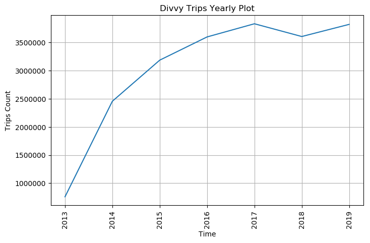

```python
plt.figure(figsize=(8,5),dpi=100)
plt.plot(year_plot['Year'],year_plot['count'])
plt.xticks(rotation=90)
plt.xlabel('Time')
plt.ylabel('Trips Count')
plt.title('Divvy Trips Yearly Plot')
plt.grid()
```

```python
month_plot=df_divvy.groupby('Month').count().orderBy('Month').toPandas()
```

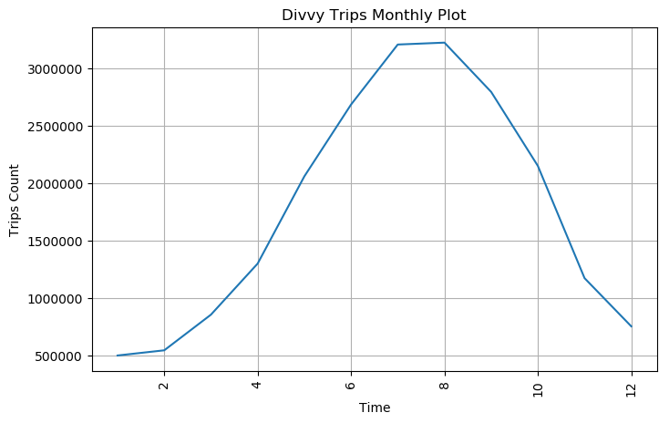

```python
plt.figure(figsize=(8,5),dpi=100)
plt.plot(month_plot['Month'],month_plot['count'])
plt.xticks(rotation=90)
plt.xlabel('Time')
plt.ylabel('Trips Count')
plt.title('Divvy Trips Monthly Plot')
plt.grid()
```

```python
dayofweek_plot=df_divvy.groupby('DayofWeek','DOW').count().orderBy('DOW').toPandas()
```

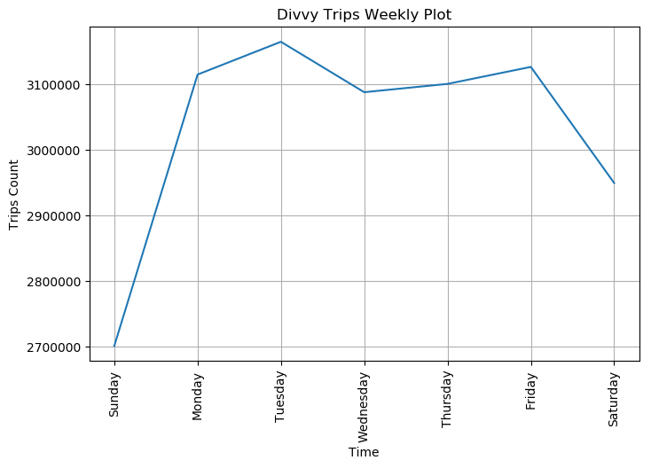

```python
plt.figure(figsize=(8,5),dpi=100)
plt.plot(dayofweek_plot['DayofWeek'],dayofweek_plot['count'])
plt.xticks(rotation=90)
plt.xlabel('Time')
plt.ylabel('Trips Count')
plt.title('Divvy Trips Weekly Plot')
plt.grid()
```

```python
df_divvy.createOrReplaceTempView("hour")
```

```python
df_hour=spark.sql('select count(`TRIP ID`) as counts, Hour, left(Hour,2) as hours, right(Hour,2) as midday \
                  from hour \
                  group by Hour \
                  order by midday,hours')
```

```python
df_hour=df_hour.toPandas()
```

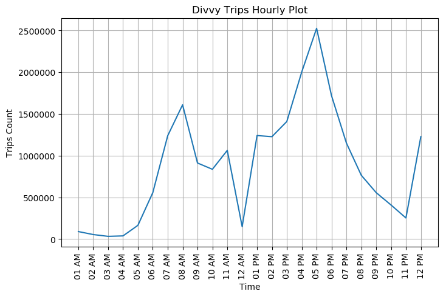

```python
plt.figure(figsize=(8,5),dpi=100)
plt.plot(df_hour['Hour'],df_hour['counts'])
plt.xticks(rotation=90)
plt.xlabel('Time')
plt.ylabel('Trips Count')
plt.title('Divvy Trips Hourly Plot')
plt.grid()
```

## b. Pie chart

```python
user_type=df_divvy.groupby('USER TYPE').count().toPandas()
```

```
Text(0.5,1,'User Type')
```

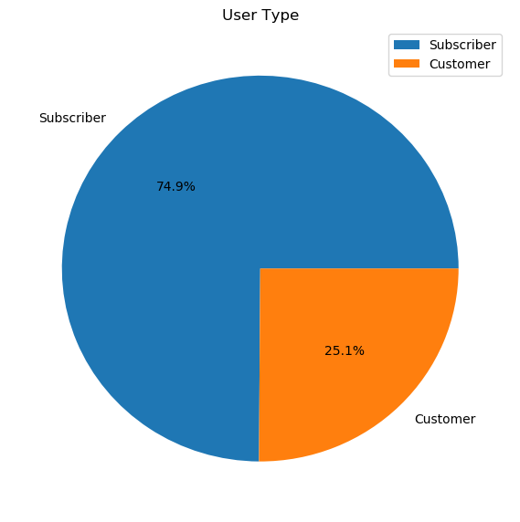

```python
plt.figure(figsize=(7,7),dpi=100)
plt.pie(user_type['count'],autopct='%1.1f%%',labels=user_type['USER TYPE'])
plt.legend()
plt.title('User Type')
```

```python
gender=df_divvy.groupby('GENDER').count().toPandas()
```

```
Text(0.5,1,'Gender')
```

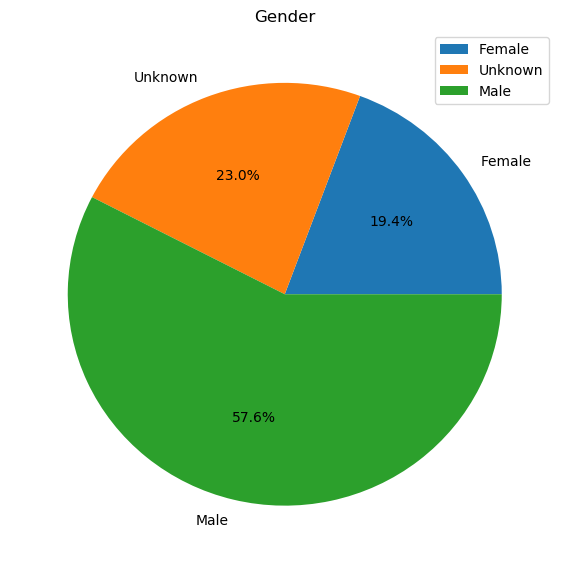

```python
plt.figure(figsize=(7,7),dpi=100)
plt.pie(gender['count'],autopct='%1.1f%%',labels=gender['GENDER'])
plt.legend()
plt.title('Gender')
```

```python
Age_range=df_divvy.groupby('Age_Range').count().orderBy("Age_Range").toPandas()
```

```
Text(0.5,1,'Age Range')
```

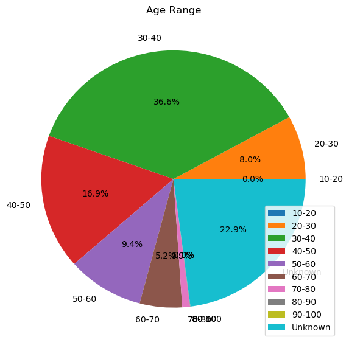

```python
plt.figure(figsize=(7,7),dpi=100)
plt.pie(Age_range['count'],autopct='%1.1f%%',labels=Age_range['Age_Range'])
plt.legend()
plt.title('Age Range')
```

### c. Bar chart

```python
user_trip=df_divvy.groupby('DayofWeek','DOW','USER TYPE').count().orderBy('DOW').toPandas()
```

```
Text(0.5,1,'Weekly Trips for Different Users')
```

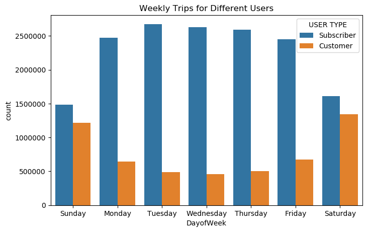

```python
plt.figure(figsize=(8,5),dpi=100)
sns.barplot(x='DayofWeek',y='count',hue='USER TYPE',data=user_trip)
plt.title("Weekly Trips for Different Users")
```

```python
user_avg_trip=df_divvy.groupby('DayofWeek','DOW','USER TYPE').agg(F.avg("TRIP DURATION").alias('Trip Length')).orderBy('DOW').toPandas()
```

```
Text(0.5,1,'Average Trips Duration for Different Users')
```

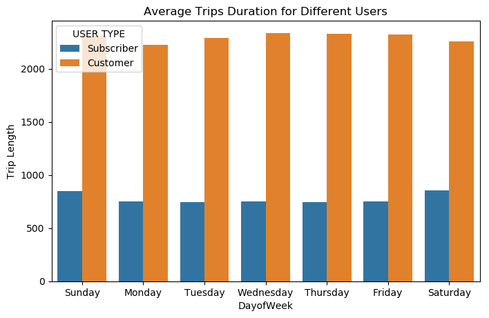

```python
plt.figure(figsize=(8,5),dpi=100)
sns.barplot(x='DayofWeek',y='Trip Length',hue='USER TYPE',data=user_avg_trip)
plt.title("Average Trips Duration for Different Users")
```

```python
top_check_out=df_divvy.groupby('FROM STATION NAME').count().orderBy('count',ascending=[0]).toPandas()
```

```python
top_check_out=top_check_out.head(20)
```

```
Text(0.5,1,'Bike Check-out at TOP20 Stations')
```

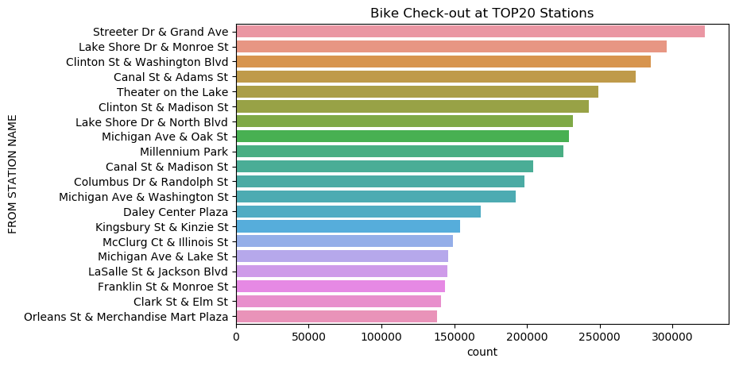

```python
plt.figure(figsize=(8,5),dpi=100)
sns.barplot(x='count',y='FROM STATION NAME',data=top_check_out)
plt.title("Bike Check-out at TOP20 Stations")
```

# 5. Model Data Prep

- For regression Model, we will merge the divvy trips dataset with the weather dataset to train ML models.
- For classification Model, we will directly train ML models on divvy trips dataset.

## a. Regression Model

### Aggregate Dataset

We want to predict the hourly bike check out number at each station. Thus, we need to aggregate the bike check out number for each station for each hour at a given date

```python
df_divvy.createOrReplaceTempView('bike')
```

```python
df_check_out=spark.sql('select `FROM STATION NAME`,day,Month,DayofWeek,Hour,count(`TRIP ID`) as check_out \
                        from bike \
                        group by `FROM STATION NAME`, day, Hour, Month, DayofWeek \
                        order by `FROM STATION NAME`, day, Hour')
```

```python
df_check_out.show()
```

```
+-------------------+----------+-----+---------+-----+---------+
|  FROM STATION NAME|       day|Month|DayofWeek| Hour|check_out|
+-------------------+----------+-----+---------+-----+---------+
|2112 W Peterson Ave|2015-05-13|    5|Wednesday|11 AM|        1|
|2112 W Peterson Ave|2015-05-14|    5| Thursday|12 PM|        1|
|2112 W Peterson Ave|2015-05-16|    5| Saturday|08 PM|        1|
|2112 W Peterson Ave|2015-05-17|    5|   Sunday|02 PM|        1|
|2112 W Peterson Ave|2015-05-17|    5|   Sunday|05 PM|        1|
|2112 W Peterson Ave|2015-05-17|    5|   Sunday|07 PM|        2|
|2112 W Peterson Ave|2015-05-17|    5|   Sunday|09 PM|        1|
|2112 W Peterson Ave|2015-05-18|    5|   Monday|10 AM|        1|
|2112 W Peterson Ave|2015-05-18|    5|   Monday|12 PM|        2|
|2112 W Peterson Ave|2015-05-21|    5| Thursday|12 PM|        1|
|2112 W Peterson Ave|2015-05-22|    5|   Friday|05 PM|        1|
|2112 W Peterson Ave|2015-05-24|    5|   Sunday|03 PM|        2|
|2112 W Peterson Ave|2015-05-25|    5|   Monday|03 PM|        1|
|2112 W Peterson Ave|2015-05-25|    5|   Monday|06 PM|        2|
|2112 W Peterson Ave|2015-05-25|    5|   Monday|07 PM|        2|
|2112 W Peterson Ave|2015-05-25|    5|   Monday|08 PM|        2|
|2112 W Peterson Ave|2015-05-27|    5|Wednesday|03 PM|        2|
|2112 W Peterson Ave|2015-05-27|    5|Wednesday|06 PM|        1|
|2112 W Peterson Ave|2015-05-28|    5| Thursday|12 PM|        2|
|2112 W Peterson Ave|2015-05-29|    5|   Friday|01 PM|        1|
+-------------------+----------+-----+---------+-----+---------+
only showing top 20 rows
```

### Merge Weather Dataset

```python
df_regression=df_check_out.join(df1_weather,['day','Hour'])
```

```python
df_regression.show(5)
```

```
+----------+-----+--------------------+-----+---------+---------+-----------+--------------------+--------+--------------+-------------+----------+------------------+--------------+----------+-------------------+---------------+-------+
|       day| Hour|   FROM STATION NAME|Month|DayofWeek|check_out|Temperature|Wet_Bulb_Temperature|Humidity|Rain_Intensity|Interval_Rain|Total_Rain|Precipitation_Type|Wind_Direction|Wind_Speed|Barometric_Pressure|Solar_Radiation|Heading|
+----------+-----+--------------------+-----+---------+---------+-----------+--------------------+--------+--------------+-------------+----------+------------------+--------------+----------+-------------------+---------------+-------+
|2015-06-03|10 AM|Clark St & Berwyn...|    6|Wednesday|        1|       14.5|                12.3|      82|           0.0|          0.0|      10.3|                 0|           103|       2.5|              996.5|            762|      0|
|2015-06-03|10 AM|Clark St & Bryn M...|    6|Wednesday|        1|       14.5|                12.3|      82|           0.0|          0.0|      10.3|                 0|           103|       2.5|              996.5|            762|      0|
|2015-06-03|10 AM|     Kosciuszko Park|    6|Wednesday|        1|       14.5|                12.3|      82|           0.0|          0.0|      10.3|                 0|           103|       2.5|              996.5|            762|      0|
|2015-06-03|10 AM|Sheffield Ave & W...|    6|Wednesday|        2|       14.5|                12.3|      82|           0.0|          0.0|      10.3|                 0|           103|       2.5|              996.5|            762|      0|
|2015-06-03|10 AM|Cannon Dr & Fulle...|    6|Wednesday|        2|       14.5|                12.3|      82|           0.0|          0.0|      10.3|                 0|           103|       2.5|              996.5|            762|      0|
+----------+-----+--------------------+-----+---------+---------+-----------+--------------------+--------+--------------+-------------+----------+------------------+--------------+----------+-------------------+---------------+-------+
only showing top 5 rows
```

```python
df_regression=df_regression.withColumn('Month', F.col('Month').cast(F.StringType()))
```

```python
df_regression=df_regression.drop('day')
```

```python
df_regression.show(5)
```

```
+-----+--------------------+-----+---------+---------+-----------+--------------------+--------+--------------+-------------+----------+------------------+--------------+----------+-------------------+---------------+-------+
| Hour|   FROM STATION NAME|Month|DayofWeek|check_out|Temperature|Wet_Bulb_Temperature|Humidity|Rain_Intensity|Interval_Rain|Total_Rain|Precipitation_Type|Wind_Direction|Wind_Speed|Barometric_Pressure|Solar_Radiation|Heading|
+-----+--------------------+-----+---------+---------+-----------+--------------------+--------+--------------+-------------+----------+------------------+--------------+----------+-------------------+---------------+-------+
|10 AM|Blue Island Ave &...|    6|Wednesday|        3|       14.5|                12.3|      82|           0.0|          0.0|      10.3|                 0|           103|       2.5|              996.5|            762|      0|
|10 AM|Dearborn St & Mon...|    6|Wednesday|        2|       14.5|                12.3|      82|           0.0|          0.0|      10.3|                 0|           103|       2.5|              996.5|            762|      0|
|10 AM|Lincoln Ave & Div...|    6|Wednesday|        2|       14.5|                12.3|      82|           0.0|          0.0|      10.3|                 0|           103|       2.5|              996.5|            762|      0|
|10 AM|Lincoln Ave & Ful...|    6|Wednesday|        5|       14.5|                12.3|      82|           0.0|          0.0|      10.3|                 0|           103|       2.5|              996.5|            762|      0|
|10 AM|Sedgwick St & Hur...|    6|Wednesday|        1|       14.5|                12.3|      82|           0.0|          0.0|      10.3|                 0|           103|       2.5|              996.5|            762|      0|
+-----+--------------------+-----+---------+---------+-----------+--------------------+--------+--------------+-------------+----------+------------------+--------------+----------+-------------------+---------------+-------+
only showing top 5 rows
```

## b. Classification

```python
df_classification=df_divvy.drop('TRIP ID','START TIME','STOP TIME','BIKE ID','DOW','BIRTH YEAR','Year','day')
df_classification=df_classification.withColumn('Month', F.col('Month').cast(F.StringType()))
```

```python
df_classification.printSchema()
```

```
root
 |-- TRIP DURATION: integer (nullable = true)
 |-- FROM STATION ID: string (nullable = true)
 |-- FROM STATION NAME: string (nullable = true)
 |-- TO STATION ID: string (nullable = true)
 |-- TO STATION NAME: string (nullable = true)
 |-- USER TYPE: string (nullable = true)
 |-- GENDER: string (nullable = false)
 |-- Month: string (nullable = true)
 |-- DayofWeek: string (nullable = true)
 |-- Hour: string (nullable = true)
 |-- Age: integer (nullable = true)
 |-- Age_Range: string (nullable = true)
```

# 6. Build Model

## a. Regression Model

### Dummy Encoding

```python
#convert relevant categorical into one hot encoded
indexer1 = StringIndexer(inputCol="FROM STATION NAME", outputCol="stationIdx").setHandleInvalid("skip")
indexer2 = StringIndexer(inputCol="Month", outputCol="dayIdx").setHandleInvalid("skip")
indexer3 = StringIndexer(inputCol="Hour", outputCol="hourIdx").setHandleInvalid("skip")
indexer4 = StringIndexer(inputCol="DayofWeek", outputCol="dayofweekIdx").setHandleInvalid("skip")

#gather all indexers as inputs to the One Hot Encoder
inputs = [indexer1.getOutputCol(), indexer2.getOutputCol(), \
          indexer3.getOutputCol(), indexer4.getOutputCol()]

#create the one hot encoder
encoder = OneHotEncoderEstimator(inputCols=inputs,  \
                                 outputCols=["stationVec", "dayVec", \
                                             "hourVec", "dayofweekVec"])

#run it through a pipeline
pipeline = Pipeline(stages=[indexer1, indexer2, indexer3, indexer4, encoder])
df_regression = pipeline.fit(df_regression).transform(df_regression)

#we have removed NAs so dont need to impute missing values.
#pipeline = pipeline.na.fill(0)

df_regression.show(5)
```

```
+-----+--------------------+-----+---------+---------+-----------+--------------------+--------+--------------+-------------+----------+------------------+--------------+----------+-------------------+---------------+-------+----------+------+-------+------------+-----------------+--------------+---…
| Hour|   FROM STATION NAME|Month|DayofWeek|check_out|Temperature|Wet_Bulb_Temperature|Humidity|Rain_Intensity|Interval_Rain|Total_Rain|Precipitation_Type|Wind_Direction|Wind_Speed|Barometric_Pressure|Solar_Radiation|Heading|stationIdx|dayIdx|hourIdx|dayofweekIdx|       stationVec|        dayVec|   …
+-----+--------------------+-----+---------+---------+-----------+--------------------+--------+--------------+-------------+----------+------------------+--------------+----------+-------------------+---------------+-------+----------+------+-------+------------+-----------------+--------------+---…
|10 AM|Broadway & Barry Ave|    6|Wednesday|        2|       14.5|                12.3|      82|           0.0|          0.0|      10.3|                 0|           103|       2.5|              996.5|            762|      0|      24.0|   2.0|   12.0|         2.0| (724,[24],[1.0])|(11,[2],[1.0])|(23…
|10 AM|Broadway & Belmon...|    6|Wednesday|        1|       14.5|                12.3|      82|           0.0|          0.0|      10.3|                 0|           103|       2.5|              996.5|            762|      0|      90.0|   2.0|   12.0|         2.0| (724,[90],[1.0])|(11,[2],[1.0])|(23…
|10 AM|   Clark St & Elm St|    6|Wednesday|        6|       14.5|                12.3|      82|           0.0|          0.0|      10.3|                 0|           103|       2.5|              996.5|            762|      0|       2.0|   2.0|   12.0|         2.0|  (724,[2],[1.0])|(11,[2],[1.0])|(23…
|10 AM|Cannon Dr & Fulle...|    6|Wednesday|        2|       14.5|                12.3|      82|           0.0|          0.0|      10.3|                 0|           103|       2.5|              996.5|            762|      0|     241.0|   2.0|   12.0|         2.0|(724,[241],[1.0])|(11,[2],[1.0])|(23…
|10 AM|Damen Ave & Welli...|    6|Wednesday|        1|       14.5|                12.3|      82|           0.0|          0.0|      10.3|                 0|           103|       2.5|              996.5|            762|      0|     263.0|   2.0|   12.0|         2.0|(724,[263],[1.0])|(11,[2],[1.0])|(23…
+-----+--------------------+-----+---------+---------+-----------+--------------------+--------+--------------+-------------+----------+------------------+--------------+----------+-------------------+---------------+-------+----------+------+-------+------------+-----------------+--------------+---…
only showing top 5 rows
```

```python
# Prepare the data by indexing the classes and putting the features into a vector.
vectorAssembler = VectorAssembler(inputCols=[ "Temperature","Wind_Speed","Precipitation_Type","stationVec", "dayVec", "hourVec", "dayofweekVec"],
                                  outputCol="features")
df_regression = vectorAssembler.transform(df_regression)
```

```python
df_regression.show(5)
```

```
+-----+--------------------+-----+---------+---------+-----------+--------------------+--------+--------------+-------------+----------+------------------+--------------+----------+-------------------+---------------+-------+----------+------+-------+------------+-----------------+--------------+---…
| Hour|   FROM STATION NAME|Month|DayofWeek|check_out|Temperature|Wet_Bulb_Temperature|Humidity|Rain_Intensity|Interval_Rain|Total_Rain|Precipitation_Type|Wind_Direction|Wind_Speed|Barometric_Pressure|Solar_Radiation|Heading|stationIdx|dayIdx|hourIdx|dayofweekIdx|       stationVec|        dayVec|   …
+-----+--------------------+-----+---------+---------+-----------+--------------------+--------+--------------+-------------+----------+------------------+--------------+----------+-------------------+---------------+-------+----------+------+-------+------------+-----------------+--------------+---…
|10 AM|Lake Shore Dr & O...|    6|Wednesday|        5|       14.5|                12.3|      82|           0.0|          0.0|      10.3|                 0|           103|       2.5|              996.5|            762|      0|      93.0|   2.0|   12.0|         2.0| (724,[93],[1.0])|(11,[2],[1.0])|(23…
|10 AM|Michigan Ave & Ma...|    6|Wednesday|        3|       14.5|                12.3|      82|           0.0|          0.0|      10.3|                 0|           103|       2.5|              996.5|            762|      0|     116.0|   2.0|   12.0|         2.0|(724,[116],[1.0])|(11,[2],[1.0])|(23…
|10 AM|Wabash Ave & Roos...|    6|Wednesday|        1|       14.5|                12.3|      82|           0.0|          0.0|      10.3|                 0|           103|       2.5|              996.5|            762|      0|       4.0|   2.0|   12.0|         2.0|  (724,[4],[1.0])|(11,[2],[1.0])|(23…
|10 AM|Broadway & Barry Ave|    6|Wednesday|        2|       14.5|                12.3|      82|           0.0|          0.0|      10.3|                 0|           103|       2.5|              996.5|            762|      0|      24.0|   2.0|   12.0|         2.0| (724,[24],[1.0])|(11,[2],[1.0])|(23…
|10 AM|Clark St & Schrei...|    6|Wednesday|        1|       14.5|                12.3|      82|           0.0|          0.0|      10.3|                 0|           103|       2.5|              996.5|            762|      0|     378.0|   2.0|   12.0|         2.0|(724,[378],[1.0])|(11,[2],[1.0])|(23…
+-----+--------------------+-----+---------+---------+-----------+--------------------+--------+--------------+-------------+----------+------------------+--------------+----------+-------------------+---------------+-------+----------+------+-------+------------+-----------------+--------------+---…
only showing top 5 rows
```

### Train Test Split

```python
# Split the data into training and test sets.
train_df, test_df =  df_regression.randomSplit([0.8, 0.2],0.0)
```

```python
train_df.select('features').show(5, truncate=False)
```

```
+------------------------------------------------------+
|features                                              |
+------------------------------------------------------+
|(767,[0,1,178,728,758,766],[19.2,0.6,1.0,1.0,1.0,1.0])|
|(767,[0,1,32,728,758,766],[19.2,0.6,1.0,1.0,1.0,1.0]) |
|(767,[0,1,208,732,758,761],[8.1,4.6,1.0,1.0,1.0,1.0]) |
|(767,[0,1,249,728,758,766],[19.2,0.6,1.0,1.0,1.0,1.0])|
|(767,[0,1,238,728,758,766],[19.2,0.6,1.0,1.0,1.0,1.0])|
+------------------------------------------------------+
only showing top 5 rows
```

### Models

#### 1. Linear Regression

```python
from pyspark.ml.regression import LinearRegression

#Elastic Net
lr = LinearRegression(featuresCol = 'features', labelCol='check_out', maxIter=10)
lrm = lr.fit(train_df)

#coefficients
print("Coefficients: " + str(lrm.coefficients))
print("Intercept: " + str(lrm.intercept))

#model summary
print("RMSE: %f" % lrm.summary.rootMeanSquaredError)
print("r2: %f" % lrm.summary.r2)
```

```
Coefficients: [0.041932522495916995,-0.002321256980964173,-0.010450662029269532,4.745866521283507,7.067809237975023,3.224426461802762,3.311205366665656,2.973568793127842,3.227395000224557,5.389998910098916,2.6386959121779485,2.8079037301265277,3.6143441290720615,3.018126364613557,8.545759244495217,2…
Intercept: -1.9583308615176738
RMSE: 3.599174
r2: 0.276115
```

```python
# Run the classifier on the test set
predictions = lrm.transform(test_df)
```

```python
from itertools import chain
attrs = sorted(
    (attr["idx"], attr["name"]) for attr in (chain(*predictions
        .schema[lrm.summary.featuresCol]
        .metadata["ml_attr"]["attrs"].values())))
#[(name, lrm.summary.pValues[idx]) for idx, name in attrs]
```

```python
from pyspark.ml.evaluation import RegressionEvaluator

eval = RegressionEvaluator(labelCol="check_out", predictionCol="prediction", metricName="rmse")

# Root Mean Square Error
rmse_1 = eval.evaluate(predictions)

# Mean Square Error
mse_1 = eval.evaluate(predictions, {eval.metricName: "mse"})

# Mean Absolute Error
mae_1 = eval.evaluate(predictions, {eval.metricName: "mae"})

# r2 - coefficient of determination
r2_1 = eval.evaluate(predictions, {eval.metricName: "r2"})
```

#### 2. Ridge Regression

```python
#Elastic Net
ridge = LinearRegression(featuresCol = 'features', labelCol='check_out', regParam=0.1, elasticNetParam=0, maxIter=10)
ridgem = ridge.fit(train_df)

#coefficients
print("Coefficients: " + str(ridgem.coefficients))
print("Intercept: " + str(ridgem.intercept))

#model summary
print("RMSE: %f" % ridgem.summary.rootMeanSquaredError)
print("r2: %f" % ridgem.summary.r2)
```

```
Coefficients: [0.04614979617918854,-0.002396797118102218,-0.010133418566576938,2.9587555308322715,5.228170118306857,1.4668131183146635,1.5544437812405927,1.226824339857696,1.4750777905643115,3.592616910490784,0.8923404012088533,1.0680851720197664,1.8552569471461404,1.2727933305347319,6.6760404597377…
Intercept: 1.5290229907691806
RMSE: 3.601028
r2: 0.275369
```

```python
# Run the classifier on the test set
predictions = ridgem.transform(test_df)
```

```python
attrs = sorted(
    (attr["idx"], attr["name"]) for attr in (chain(*predictions
        .schema[ridgem.summary.featuresCol]
        .metadata["ml_attr"]["attrs"].values())))
#[(name, lrm.summary.pValues[idx]) for idx, name in attrs]
```

```python
eval_2 = RegressionEvaluator(labelCol="check_out", predictionCol="prediction", metricName="rmse")

# Root Mean Square Error
rmse_2 = eval_2.evaluate(predictions)

# Mean Square Error
mse_2 = eval_2.evaluate(predictions, {eval_2.metricName: "mse"})

# Mean Absolute Error
mae_2 = eval_2.evaluate(predictions, {eval_2.metricName: "mae"})

# r2 - coefficient of determination
r2_2 = eval_2.evaluate(predictions, {eval_2.metricName: "r2"})
```

#### 3. Ranfom Forest

```python
%%time
from pyspark.ml.tuning import ParamGridBuilder, CrossValidator
from pyspark.ml.regression import RandomForestRegressor
rfr = RandomForestRegressor(maxDepth=5, numTrees=15, labelCol= 'check_out', predictionCol = 'prediction')
rfr_model = rfr.fit(train_df)
```

```
CPU times: user 31.3 ms, sys: 7.38 ms, total: 38.7 ms
Wall time: 1min 23s
```

```python
# Run the classifier on the test set
predictions_rf = rfr_model.transform(test_df)
```

```python
eval_3 = RegressionEvaluator(labelCol="check_out", predictionCol="prediction", metricName="rmse")

# Root Mean Square Error
rmse_3 = eval_3.evaluate(predictions_rf)

# Mean Square Error
mse_3 = eval_3.evaluate(predictions_rf, {eval_3.metricName: "mse"})

# Mean Absolute Error
mae_3 = eval_3.evaluate(predictions_rf, {eval_3.metricName: "mae"})

# r2 - coefficient of determination
r2_3 = eval_3.evaluate(predictions_rf, {eval_3.metricName: "r2"})
```

```python
# explainer = shap.TreeExplainer(predictions_rf, predictions_rf)
# shap_values = explainer(predictions_rf)
# feature_names = [
#     a + ": " + str(b) for a,b in zip(X.columns, np.abs(shap_values.values).mean(0).round(2))
# ]

# shap.summary_plot(shap_values, predictions_rf, max_display=predictions_rf.shape[1],
#                   feature_names=feature_names)
```

#### RF Fine Tune

let's run this after we finish everything else

```python
rfr_tune = RandomForestRegressor( labelCol= 'check_out', predictionCol = 'prediction')
evalutaor_rfr =RegressionEvaluator(labelCol="check_out", predictionCol="prediction", metricName="rmse")

paramGrid_rfr = ParamGridBuilder() \
    .addGrid(rfr_tune.maxDepth , [5, 10, 20]) \
    .addGrid(rfr_tune.numTrees , [10, 50 , 100]) \
    .addGrid(rfr_tune.minInstancesPerNode , [10, 50]) \
    .build()


cv = CrossValidator(estimator=rfr_tune, estimatorParamMaps=paramGrid_rfr, evaluator=evalutaor_rfr, numFolds=3)
```

I have tried to run below code for multiple times, however the code does not provide output due to memory error. I also tried to just run one random forest regression with some higher-value hyper-parameters(# of trees to 100), which also brok the algorithm due to memory limit.

Would recommend to use more advanced machine for fitting the random forest model.

For the classification model, since the default model naturally already take more time than than default regression task. I decided to not tune it.

```python
eval_4 = RegressionEvaluator(labelCol="check_out", predictionCol="prediction", metricName="rmse")

# Root Mean Square Error
rmse_4 = eval_4.evaluate(predictions_rf)

# Mean Square Error
mse_4 = eval_4.evaluate(predictions_rf, {eval_4.metricName: "mse"})

# Mean Absolute Error
mae_4 = eval_4.evaluate(predictions_rf, {eval_4.metricName: "mae"})

# r2 - coefficient of determination
r2_4 = eval_4.evaluate(predictions_rf, {eval_4.metricName: "r2"})
```

### Merge Result

```python
regression_result = pd.DataFrame()
regression_result['Model'] = ['Linear Regression','Ridge Regression', 'Random Forest']
regression_result['RMSE'] = [rmse_1, rmse_2, rmse_3]
regression_result['MSE'] = [mse_1, mse_2, mse_3]
regression_result['MAE'] = [mae_1, mae_2, mae_3]
regression_result['R2'] = [r2_1, r2_2, r2_3]

regression_result
```

|  | Model | RMSE | MSE | MAE | R2 |
| --- | --- | --- | --- | --- | --- |
| 0 | Linear Regression | 3.580245 | 12.818151 | 1.873999 | 0.276616 |
| 1 | Ridge Regression | 3.582061 | 12.831160 | 1.863996 | 0.275882 |
| 2 | Random Forest | 3.821083 | 14.600673 | 2.029967 | 0.176021 |

## b. Classification Model

```python
df_classification.printSchema()
```

```
root
 |-- TRIP DURATION: integer (nullable = true)
 |-- FROM STATION ID: string (nullable = true)
 |-- FROM STATION NAME: string (nullable = true)
 |-- TO STATION ID: string (nullable = true)
 |-- TO STATION NAME: string (nullable = true)
 |-- USER TYPE: string (nullable = true)
 |-- GENDER: string (nullable = false)
 |-- Month: string (nullable = true)
 |-- DayofWeek: string (nullable = true)
 |-- Hour: string (nullable = true)
 |-- Age: integer (nullable = true)
 |-- Age_Range: string (nullable = true)
```

```python
df_classification.show(5)
```

```
+-------------+---------------+--------------------+-------------+--------------------+----------+------+-----+---------+-----+---+---------+
|TRIP DURATION|FROM STATION ID|   FROM STATION NAME|TO STATION ID|     TO STATION NAME| USER TYPE|GENDER|Month|DayofWeek| Hour|Age|Age_Range|
+-------------+---------------+--------------------+-------------+--------------------+----------+------+-----+---------+-----+---+---------+
|          521|            117|Wilton Ave & Belm...|          229|Southport Ave & R...|Subscriber|Female|   12| Thursday|05 PM| 31|    30-40|
|          256|            301|Clark St & Schill...|          138|Clybourn Ave & Di...|Subscriber|  Male|   12| Thursday|05 PM| 30|    30-40|
|          134|            465|Marine Dr & Ainsl...|          251|Clarendon Ave & L...|Subscriber|Female|   12| Thursday|05 PM| 35|    30-40|
|          995|            333|Ashland Ave & Bla...|          198|Green St (Halsted...|Subscriber|  Male|   12| Thursday|05 PM| 47|    40-50|
|          177|             48|Larrabee St & Kin...|          111|Sedgwick St & Hur...|Subscriber|  Male|   12| Thursday|05 PM| 32|    30-40|
+-------------+---------------+--------------------+-------------+--------------------+----------+------+-----+---------+-----+---+---------+
only showing top 5 rows
```

### Dummy Encoding

```python
df_classification = df_classification.withColumn('is_subscriber', F.when(F.col("USER TYPE") == 'Subscriber', 1).otherwise(0))
```

```python
#convert relevant categorical into one hot encoded
indexer1 = StringIndexer(inputCol="FROM STATION NAME", outputCol="stationIdx").setHandleInvalid("skip")
indexer2 = StringIndexer(inputCol="Month", outputCol="monthIdx").setHandleInvalid("skip")
indexer3 = StringIndexer(inputCol="Hour", outputCol="hourIdx").setHandleInvalid("skip")
indexer4 = StringIndexer(inputCol="DayofWeek", outputCol="dayofweekIdx").setHandleInvalid("skip")
indexer5 = StringIndexer(inputCol="GENDER", outputCol="genderIdx").setHandleInvalid("skip")
indexer6 = StringIndexer(inputCol="Age_Range", outputCol="agerangeIdx").setHandleInvalid("skip")


#gather all indexers as inputs to the One Hot Encoder
inputs = [indexer1.getOutputCol(), indexer2.getOutputCol(), \
          indexer3.getOutputCol(), indexer4.getOutputCol(), \
          indexer5.getOutputCol(), indexer6.getOutputCol()]

#create the one hot encoder
encoder = OneHotEncoderEstimator(inputCols=inputs,  \
                                 outputCols=["stationVec", "monthVec", "hourVec", \
                                             "dayofweekVec","agerangeVec","genderVec"])

#run it through a pipeline
pipeline = Pipeline(stages=[indexer1,indexer2,indexer3,indexer4,indexer5,indexer6,encoder])

df_classification2 = pipeline.fit(df_classification).transform(df_classification)

#we have removed NAs so dont need to impute missing values.
#pipeline = pipeline.na.fill(0)

df_classification2.show(5)
```

```
+-------------+---------------+--------------------+-------------+--------------------+----------+------+-----+---------+-----+---+---------+-------------+----------+--------+-------+------------+---------+-----------+--------------+-------------+-------------+-------------+--------------+----------…
|TRIP DURATION|FROM STATION ID|   FROM STATION NAME|TO STATION ID|     TO STATION NAME| USER TYPE|GENDER|Month|DayofWeek| Hour|Age|Age_Range|is_subscriber|stationIdx|monthIdx|hourIdx|dayofweekIdx|genderIdx|agerangeIdx|       hourVec| dayofweekVec|    genderVec|  agerangeVec|      monthVec|       sta…
+-------------+---------------+--------------------+-------------+--------------------+----------+------+-----+---------+-----+---+---------+-------------+----------+--------+-------+------------+---------+-----------+--------------+-------------+-------------+-------------+--------------+----------…
|          521|            117|Wilton Ave & Belm...|          229|Southport Ave & R...|Subscriber|Female|   12| Thursday|05 PM| 31|    30-40|            1|      41.0|     9.0|    0.0|         3.0|      2.0|        0.0|(23,[0],[1.0])|(6,[3],[1.0])|(9,[0],[1.0])|    (2,[],[])|(11,[9],[1.0])| (747,[41]…
|          256|            301|Clark St & Schill...|          138|Clybourn Ave & Di...|Subscriber|  Male|   12| Thursday|05 PM| 30|    30-40|            1|      65.0|     9.0|    0.0|         3.0|      0.0|        0.0|(23,[0],[1.0])|(6,[3],[1.0])|(9,[0],[1.0])|(2,[0],[1.0])|(11,[9],[1.0])| (747,[65]…
|          134|            465|Marine Dr & Ainsl...|          251|Clarendon Ave & L...|Subscriber|Female|   12| Thursday|05 PM| 35|    30-40|            1|     271.0|     9.0|    0.0|         3.0|      2.0|        0.0|(23,[0],[1.0])|(6,[3],[1.0])|(9,[0],[1.0])|    (2,[],[])|(11,[9],[1.0])|(747,[271]…
|          995|            333|Ashland Ave & Bla...|          198|Green St (Halsted...|Subscriber|  Male|   12| Thursday|05 PM| 47|    40-50|            1|     192.0|     9.0|    0.0|         3.0|      0.0|        2.0|(23,[0],[1.0])|(6,[3],[1.0])|(9,[2],[1.0])|(2,[0],[1.0])|(11,[9],[1.0])|(747,[192]…
|          177|             48|Larrabee St & Kin...|          111|Sedgwick St & Hur...|Subscriber|  Male|   12| Thursday|05 PM| 32|    30-40|            1|      31.0|     9.0|    0.0|         3.0|      0.0|        0.0|(23,[0],[1.0])|(6,[3],[1.0])|(9,[0],[1.0])|(2,[0],[1.0])|(11,[9],[1.0])| (747,[31]…
+-------------+---------------+--------------------+-------------+--------------------+----------+------+-----+---------+-----+---+---------+-------------+----------+--------+-------+------------+---------+-----------+--------------+-------------+-------------+-------------+--------------+----------…
only showing top 5 rows
```

```python
# Prepare the data by indexing the classes and putting the features into a vector.
vectorAssembler = VectorAssembler(inputCols=["stationVec", "monthVec", \
                                             "hourVec", "dayofweekVec",\
                                             "agerangeVec","genderVec"],
                                  outputCol="features")
df_classification3 = vectorAssembler.transform(df_classification2)
```

### Models

```python
# Split the data into training and test sets.
train_df, test_df =  df_classification3.randomSplit([0.8, 0.2],0.0)
```

```python
train_df.select('features').show(5, truncate=False)
```

```
+---------------------------------------------------------+
|features                                                 |
+---------------------------------------------------------+
|(798,[153,752,767,781,787,794],[1.0,1.0,1.0,1.0,1.0,1.0])|
|(798,[71,755,761,781,787,791],[1.0,1.0,1.0,1.0,1.0,1.0]) |
|(798,[87,752,766,781,787,789],[1.0,1.0,1.0,1.0,1.0,1.0]) |
|(798,[268,756,760,781,787,791],[1.0,1.0,1.0,1.0,1.0,1.0])|
|(798,[9,753,759,787,794],[1.0,1.0,1.0,1.0,1.0])          |
+---------------------------------------------------------+
only showing top 5 rows
```

#### 1. Logistic Regression

```python
from pyspark.ml.classification import LogisticRegression
from pyspark.ml.evaluation import BinaryClassificationEvaluator

# Set parameters for Logistic Regression
lgr = LogisticRegression(featuresCol = 'features', labelCol='is_subscriber', maxIter=10)

# Fit the model to the data.
lgrm = lgr.fit(train_df)

# Given a dataset, predict each point's label, and show the results.
predictions = lgrm.transform(test_df)
predictions.select("is_subscriber", "prediction").show(5)
```

```
+-------------+----------+
|is_subscriber|prediction|
+-------------+----------+
|            1|       1.0|
|            1|       1.0|
|            1|       1.0|
|            1|       1.0|
|            1|       1.0|
+-------------+----------+
only showing top 5 rows
```

```python
#print evaluation metrics
evaluator = BinaryClassificationEvaluator(labelCol="is_subscriber",rawPredictionCol="prediction")
auc_lgr = evaluator.evaluate(predictions, {evaluator.metricName: "areaUnderROC"})
print("AUC:",auc_lgr)
```

```
AUC: 0.9561757576993598
```

```python
is_subscriber_array = predictions.select("is_subscriber").toPandas().values
prediction_array = predictions.select("prediction").toPandas().values
```

```python
# BinaryClassificationEvaluator has no built-in function for accuracy and f1, so use sklearn
from sklearn.metrics import f1_score
from sklearn.metrics import accuracy_score

acc_lgr = accuracy_score(is_subscriber_array, prediction_array)
f1_lgr = f1_score(is_subscriber_array, prediction_array)
print("accuracy:", acc_lgr)
print("f1 score:",f1_lgr)
```

```
accuracy: 0.9768360899948634
f1 score: 0.9847270450329075
```

#### 2. naive bayes

```python
from pyspark.ml.classification import NaiveBayes
nb = NaiveBayes().setFeaturesCol("features").setLabelCol("is_subscriber").setSmoothing(1.0).setModelType("multinomial")
nbModel = nb.fit(train_df)
predictions = nbModel.transform(test_df)
predictions.select("is_subscriber", "prediction").show(5)
```

```
+-------------+----------+
|is_subscriber|prediction|
+-------------+----------+
|            1|       1.0|
|            1|       1.0|
|            1|       1.0|
|            1|       1.0|
|            0|       0.0|
+-------------+----------+
only showing top 5 rows
```

```python
#print evaluation metrics
evaluator = BinaryClassificationEvaluator(labelCol="is_subscriber",rawPredictionCol="prediction")
auc_nb = evaluator.evaluate(predictions, {evaluator.metricName: "areaUnderROC"})
print("AUC:",auc_nb)
```

[output not shown]

```python
is_subscriber_array = predictions.select("is_subscriber").toPandas().values
prediction_array = predictions.select("prediction").toPandas().values
```

```python
# BinaryClassificationEvaluator has no built-in function for accuracy and f1, so use sklearn
from sklearn.metrics import f1_score
from sklearn.metrics import accuracy_score
acc_nb = accuracy_score(is_subscriber_array, prediction_array)
f1_nb = f1_score(is_subscriber_array, prediction_array)
print("accuracy:",acc_nb)
print("f1 score:",f1_nb)
```

```
accuracy: 0.9760219118513891
f1 score: 0.9841905395193071
```

#### 3. Ranform Forest

```python
%%time
from pyspark.ml.tuning import ParamGridBuilder, CrossValidator
from pyspark.ml.classification import RandomForestClassifier
rfc = RandomForestClassifier(labelCol="is_subscriber",predictionCol="prediction")
rfc_model = rfc.fit(train_df)
```

```
CPU times: user 75.8 ms, sys: 22.3 ms, total: 98.1 ms
Wall time: 8min 6s
```

```python
predictions_rfc = rfc_model.transform(test_df)
predictions_rfc.select("is_subscriber", "prediction").show(5)
```

```
+-------------+----------+
|is_subscriber|prediction|
+-------------+----------+
|            1|       1.0|
|            1|       1.0|
|            1|       1.0|
|            1|       1.0|
|            0|       1.0|
+-------------+----------+
only showing top 5 rows
```

```python
is_subscriber_rfc_array = predictions_rfc.select("is_subscriber").toPandas().values
prediction_rfc_array = predictions_rfc.select("prediction").toPandas().values
```

```python
# BinaryClassificationEvaluator has no built-in function for accuracy and f1, so use sklearn
from sklearn.metrics import f1_score, accuracy_score, auc

acc_rfc = accuracy_score(is_subscriber_rfc_array, prediction_rfc_array)
f1_rfc = f1_score(is_subscriber_rfc_array, prediction_rfc_array)
auc_rfc = auc(is_subscriber_rfc_array, prediction_rfc_array)
print("accuracy:", acc_rfc)
print("f1 score:",f1_rfc)
print("AUC score:",auc_rfc)
```

[output not shown]

### Merge Result

```python
classification_result = pd.DataFrame()
classification_result['Model'] = ['Logistic Regression','Naive Bayes', 'Random Forest']
classification_result['Accuracy'] = [acc_lgr, acc_nb, acc_rfc]
classification_result['F1'] = [f1_lgr, f1_nb, f1_rfc]
classification_result['AUC'] = [ auc_lgr, auc_nb, auc_rfc]
classification_result
```

[output not shown]